# R Training session.Rightcare Team

22/03/2022

## Session 1. Introduction

## Session content

- **1.Accessing the data**
  - This section will cover how to import data from Excel and CSV files into R,also how to connect to SQL databases using ODBC and RDB packages.
- **2.Summarizing data**
  - We will explore several Exploratory Data Analysis (EDA) methods to assess the analysis techniques we can apply to our data
- **3.Exporting data**
  - Different ways of exporting the data into CSV and Excel
- **4.Data visualization using GGPLOT2**
  - Using GGPLOT2 package to build plots in R. This is a framework in R designed to build graphics in layers, by adding different components to the plot once step at a time. The ggplot2 package allow users to improve the quality and aesthetics of the graphics we produce.
- **5.Markdown Language**
  - Markdown is a lightweight markup language that you can use to add formatting elements to plaintext text documents.

## R Studio IDE

We use RStudio as the premiered IDE to create analytical products in R. Advantages of this tool: - Combine console, file explorer, code editor and environment into a single window. - Debug code and profile shiny apps - Create different workspaces for different projects - Integrate code development with Git and Github for version control and team project work

This is an example of Rstudio https://www.rstudio.com/products/rstudio/

Panes:Source,Console,Environment,History..,  
User can customize them)

[figure not shown]

[figure not shown]

## Getting help when coding in R

R is built around functions, so probably you will end up combining them to obtain your results. As in example below

```r
Var <-c("Beds","Patients","Metric")
Num <-c(132,2300,'RAS')
Metricv <- round(c(20.04,126.13,86.47),digits=0)

Round <-cbind.data.frame(Var,Num,Metricv)
head(Round)
```

```
##        Var  Num Metricv
## 1     Beds  132      20
## 2 Patients 2300     126
## 3   Metric  RAS      86
```

```r
# We use help() and ? functions to obtain information from any R command
help(round)
```

```
## starting httpd help server ... done
```

```r
?(round)
```

## 1. Accessing the data I

In R you can access the data in different ways

**Crating a new data set** - Entering manually: R allows you bind together vectors (defined by the concatenate c() function) in columns of rows to form a data.frame object.(As we saw in previous slide)

**Importing data from CSV** - You can use two functions *read.csv()* or *read_csv()* from readr package included in the Tidyverse universe, to import CSV files into R. The readr package makes it easy to get rectangular data out of comma separated (csv), tab separated (tsv) or fixed width files (fwf) and into R

```r
# Using read.delim() function to input online texfile from URL:
online_data <-
  read.delim("http://www.sthda.com/upload/boxplot_format.txt")
head(online_data)
```

```
##    Nom variable Group
## 1 IND1       10     A
## 2 IND2        7     A
## 3 IND3       20     A
## 4 IND4       14     A
## 5 IND5       14     A
## 6 IND6       12     A
```

## 1. Accessing the data II

**Importing data from csv**

```r
Car_speeds <-read_csv(file = 'Figures/car_speeds.csv')
head(Car_speeds)
```

```
## # A tibble: 6 x 3
##   Color Speed State
##   <chr> <dbl> <chr>
## 1 Blue     32 NewMexico
## 2 Red      45 Arizona
## 3 Blue   -999 Colorado
## 4 White    34 Arizona
## 5 REd      25 Arizona
## 6 Blue     41 NewMexico
```

## 1. Accessing the data III

**ODBC** Open Database Connectivity (ODBC) is a protocol that you can use to connect a Microsoft Access database to an external data source such as Microsoft SQL Server

```r
library(DBI)
library(odbc)

con <- dbConnect(odbc::odbc()
                 , Driver="SQL Server"
                 , Server = "PRODNHSESQL101"
                 , Trusted_Connection="yes")


SQL_query <- dbGetQuery(con,
              "SELECT TOP (100) [Dataset]
              ,[WeekEnding]
              ,[Provider_Code],[CCG_Code],[Activity_Treatment_Function_Code],[Tci_Date]
              ,[Procedure_Priority_Code],[Proposed_Procedure_Opcs_Code]
              ,[AgeBand_at_WeekEnding]
              FROM [NHSE_PSDM_COVID19].[mpi].[WLMDS_Open_ASI_Combined]
")

head(SQL_query)
```

```
##             Dataset WeekEnding Provider_Code CCG_Code
## 1 Open Pathways ASI 2022-03-13           RA7     <NA>
## 2 Open Pathways ASI 2021-08-29           RA7     <NA>
## 3 Open Pathways ASI 2021-12-26           RX1     <NA>
## 4 Open Pathways ASI 2022-01-30           RTH     <NA>
## 5 Open Pathways ASI 2021-10-24           RTR     <NA>
## 6 Open Pathways ASI 2022-03-13           RHQ     <NA>
##   Activity_Treatment_Function_Code Tci_Date Procedure_Priority_Code
## 1                              251     <NA>                    <NA>
## 2                              311     <NA>                    <NA>
## 3                              340     <NA>                    <NA>
## 4                              101     <NA>                    <NA>
## 5                              103     <NA>                    <NA>
## 6                              650     <NA>                    <NA>
##   Proposed_Procedure_Opcs_Code AgeBand_at_WeekEnding
## 1                         <NA>                  <NA>
## 2                         <NA>                  <NA>
## 3                         <NA>                  <NA>
## 4                         <NA>                  <NA>
## 5                         <NA>                  <NA>
## 6                         <NA>                  <NA>
```

**Importing data from Excel**

```r
#library(readxl)
#library(writexl)
#wdata <- read_excel("Figures/shopping.xls", sheet = "Sheet1")
#wdata
```

## 2. Summarising data

We can use two main commands to summarize a dataset set of variables

**2.1. Visually by using the plot function**

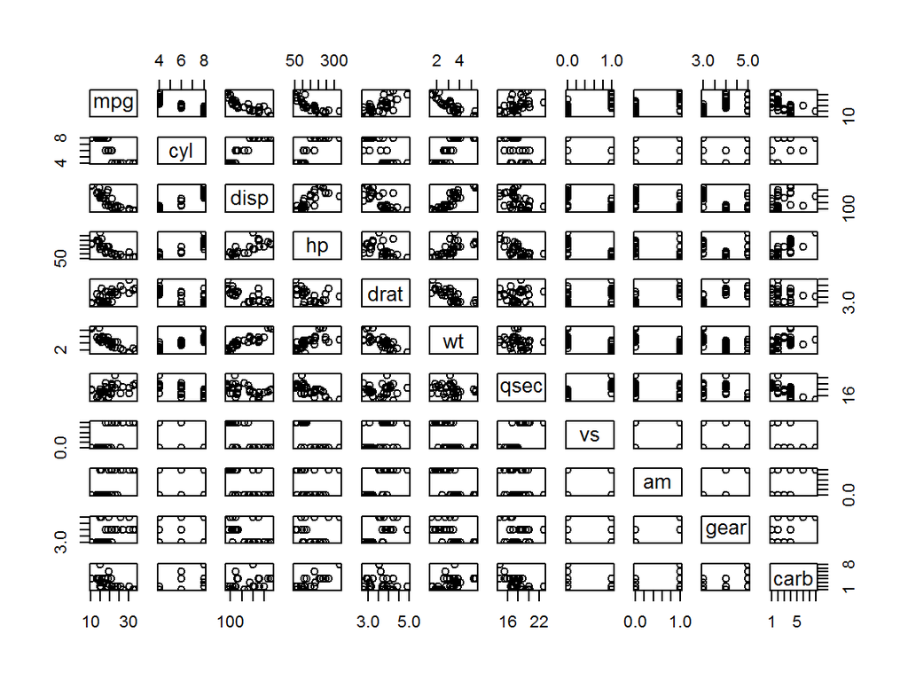

```r
plot(mtcars)
```

## 2.2 Summarising data

We can include a set of basic descriptive statistics to help us understand different distributions present in our data

```r
summary(mtcars)
```

```
##       mpg             cyl             disp             hp
##  Min.   :10.40   Min.   :4.000   Min.   : 71.1   Min.   : 52.0
##  1st Qu.:15.43   1st Qu.:4.000   1st Qu.:120.8   1st Qu.: 96.5
##  Median :19.20   Median :6.000   Median :196.3   Median :123.0
##  Mean   :20.09   Mean   :6.188   Mean   :230.7   Mean   :146.7
##  3rd Qu.:22.80   3rd Qu.:8.000   3rd Qu.:326.0   3rd Qu.:180.0
##  Max.   :33.90   Max.   :8.000   Max.   :472.0   Max.   :335.0
##       drat             wt             qsec             vs
##  Min.   :2.760   Min.   :1.513   Min.   :14.50   Min.   :0.0000
##  1st Qu.:3.080   1st Qu.:2.581   1st Qu.:16.89   1st Qu.:0.0000
##  Median :3.695   Median :3.325   Median :17.71   Median :0.0000
##  Mean   :3.597   Mean   :3.217   Mean   :17.85   Mean   :0.4375
##  3rd Qu.:3.920   3rd Qu.:3.610   3rd Qu.:18.90   3rd Qu.:1.0000
##  Max.   :4.930   Max.   :5.424   Max.   :22.90   Max.   :1.0000
##        am              gear            carb
##  Min.   :0.0000   Min.   :3.000   Min.   :1.000
##  1st Qu.:0.0000   1st Qu.:3.000   1st Qu.:2.000
##  Median :0.0000   Median :4.000   Median :2.000
##  Mean   :0.4062   Mean   :3.688   Mean   :2.812
##  3rd Qu.:1.0000   3rd Qu.:4.000   3rd Qu.:4.000
##  Max.   :1.0000   Max.   :5.000   Max.   :8.000
```

## **2.3 Desribe variables type and length**

```r
str(mtcars)
```

```
## 'data.frame':    32 obs. of  11 variables:
##  $ mpg : num  21 21 22.8 21.4 18.7 18.1 14.3 24.4 22.8 19.2 ...
##  $ cyl : num  6 6 4 6 8 6 8 4 4 6 ...
##  $ disp: num  160 160 108 258 360 ...
##  $ hp  : num  110 110 93 110 175 105 245 62 95 123 ...
##  $ drat: num  3.9 3.9 3.85 3.08 3.15 2.76 3.21 3.69 3.92 3.92 ...
##  $ wt  : num  2.62 2.88 2.32 3.21 3.44 ...
##  $ qsec: num  16.5 17 18.6 19.4 17 ...
##  $ vs  : num  0 0 1 1 0 1 0 1 1 1 ...
##  $ am  : num  1 1 1 0 0 0 0 0 0 0 ...
##  $ gear: num  4 4 4 3 3 3 3 4 4 4 ...
##  $ carb: num  4 4 1 1 2 1 4 2 2 4 ...
```

## **2.4 Obtain set of variable names from dataset**

```r
names(mtcars)
```

```
##  [1] "mpg"  "cyl"  "disp" "hp"   "drat" "wt"   "qsec" "vs"   "am"   "gear"
## [11] "carb"
```

## **3. Exporting data**

In R you can export data as .csv file using this structure:

**write.csv(Dataframe_name,“Path to export the DataFrame/File Name.csv”, row.names = TRUE)**

```r
df <- data.frame(Name = c("Jon", "Bill", "Maria", "Tom", "Emma"),
                 Age = c(23,41,32,55,40)
                 )
print (df)
```

```
##    Name Age
## 1   Jon  23
## 2  Bill  41
## 3 Maria  32
## 4   Tom  55
## 5  Emma  40
```

To export the above DataFrame to a csv file we use

**write.csv(df,“Figures/exported_data.csv”, row.names = TRUE)**

## 3. Exporting data (II)

Vanilla csv sport command

```r
write.csv(df,"Figures/exported_data.csv", row.names = TRUE)
```

Sometimes we can improve the above code by including a time stamp in it: - using the paste0() function we can add current time with a custom format to the csv output file name

**write.csv(df,paste0(“Figures/exported_data”,“*",format(Sys.time(),"%Y-%m-%d*%H:%M”),“.csv”), row.names = TRUE)**

```r
write.csv(df,paste0("Figures/exported_data","_",format(Sys.time(),"%Y-%m-%d_%H:%M"),".csv"), row.names = TRUE)
```

## 4. Data visualization using ggplot2

**What is ggplot2?**

ggplot2 is a system for declaratively creating graphics, based on The Grammar of Graphics. You provide the data, tell ggplot2 how to map variables to aesthetics, what graphical primitives to use, and it takes care of the details

```r
# The easiest way to get ggplot2 is to install the whole tidyverse:
#install.packages("tidyverse")
library(tidyverse)
# Alternatively, install just ggplot2:
# install.packages("ggplot2")
library(ggplot2)
# Or the development version from GitHub:
# install.packages("devtools")
#devtools::install_github("tidyverse/ggplot2")
```

Important resource to understand how the basic ggplot2 plots are built

https://github.com/rstudio/cheatsheets/blob/master/data-visualization-2.1.pdf https://ggplot2.tidyverse.org/

## 4. Data visualization using ggplot2(I)

**USAGE** Think about ggplot2 as building a visualization by layers:

**1.** First we load the dataset we will plot using ggplot() function

**2.** Then we need to provide an aesthetic mapping aes() to include colour as a way of segmenting the plot

**3.** Finally we add a layer with the type of geometry we require (line, bar or dots chart)

**4.** On top of that we can apply faceting grouping different plots into a single image (small multiples)

**5.** And also we can specify coordinate systems coord_flig()

-(new layer to add more detail to the original plot)

## 4.1 Example of plotting with GGPLOT2

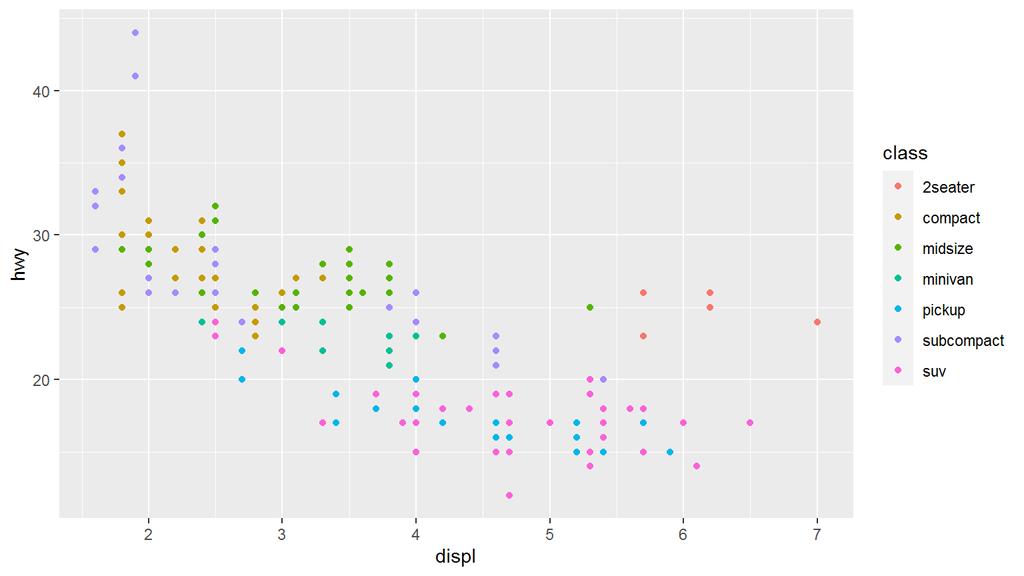

```r
library(ggplot2)

ggplot(mpg, aes(displ, hwy, colour = class)) +
  geom_point()
```

We can combine line and dot charts on different layers

## 4.2 Combined geoms in ggplot2

We can combine lines and dots on the same graph

```r
Var <-c("Patients","Patients","Patients")
Num <-c(132,2300,2100)
Dates <- as.Date(c("2007-06-21", "2007-06-22","2007-06-23"))

Mydata <-cbind.data.frame(Var,Num,Dates)
head(Mydata)
```

```
##        Var  Num      Dates
## 1 Patients  132 2007-06-21
## 2 Patients 2300 2007-06-22
## 3 Patients 2100 2007-06-23
```

```r
str(Mydata)
```

```
## 'data.frame':    3 obs. of  3 variables:
##  $ Var  : chr  "Patients" "Patients" "Patients"
##  $ Num  : num  132 2300 2100
##  $ Dates: Date, format: "2007-06-21" "2007-06-22" ...
```

## 4.3 Combined output

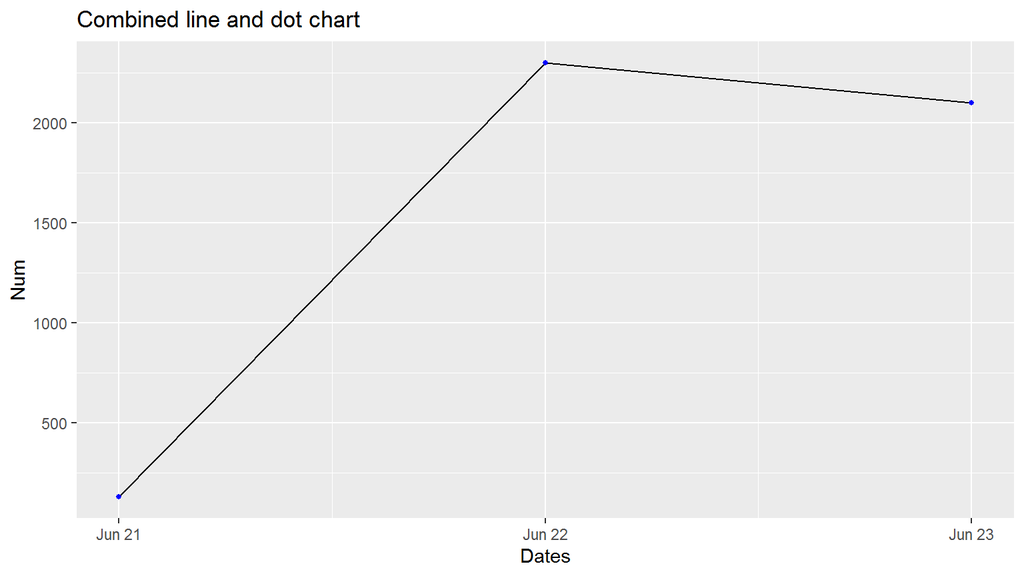

## 5. Markdown Language

Markdown is a lightweight markup language that you can use to add formatting elements to plaintext text documents. Created by John Gruber in 2004, Markdown is now one of the world’s most popular markup languages.

[figure not shown]

Markdown Guide https://www.markdownguide.org/getting-started/ https://github.com/rstudio/rmarkdown-book/issues/30 https://www.rstudio.com/wp-content/uploads/2015/02/rmarkdown-cheatsheet.pdf

## 6. Resources

- How to import data from Excel into R studio. R programming for beginners https://www.youtube.com/watch?v=cnD1op2Oo3M
- R Cheatsheets https://www.rstudio.com/resources/cheatsheets/ https://www.rstudio.com/wp-content/uploads/2015/02/rmarkdown-cheatsheet.pdf